# Part II - Ford GoBike Data Exploration

## by Oluwaseyitan Agbaje

## Investigation Overview

In this analysis, I investigated bike share rider's demographic data and characteristics as it relates to the bike ride counts and average ride duration. In addition, I was able to determine the popular bike stations as well as the busiest times and days for bike rides.

## Dataset Overview

This dataset used covers information of about 174,952 individual rides made in a bike-sharing system covering the greater San Francisco Bay area in the month of February 2019. Each ride data consists of up to 16 variables including the ride characteristics , the rider's demographic and the rider's characteristics.

## 1. Demographics of Bike Riders

Men and adults aged 18 - 39 years were the highest users of Ford GoBikes

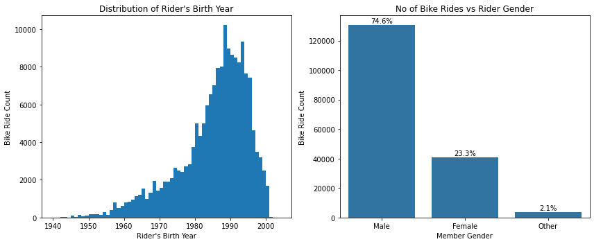

## 2. Rider's Characteristics

Subscribers to the Ford GoBike Bikes acounted for majority of the bike rides. Only ~10% of the bike rides is attributed to rides by individuals enrolled in the Bike Share for All Initiative (BSFA) for low income individuals.

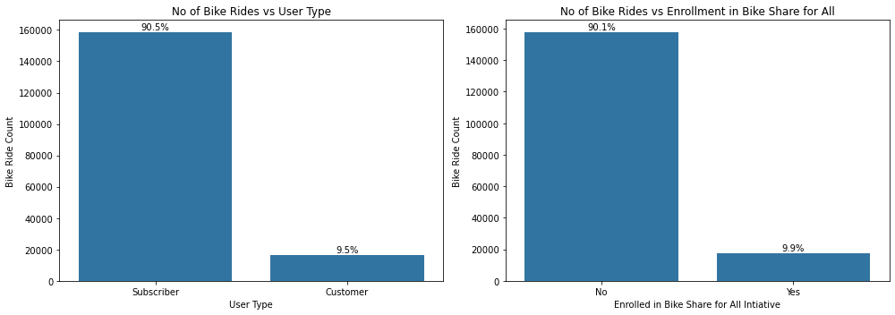

## 3. Average Ride Time

The average ride duration in February 2019 is 5-13 mins

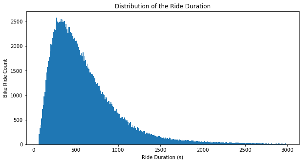

## 4. Top 10 Popular Bike Start and End Stations

The top 2 popular start and end bike stations are Market Street at 10 St and San Francisco Caltrain Station 2

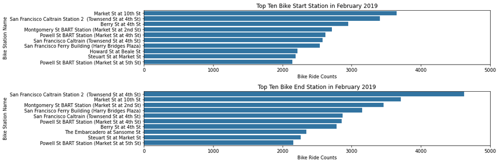

## 5. Popular Bike Ride Times and Days

Thursdays were the most popular bike rides days and the peak times for bike rides were 7-9 a.m. and 4-6 p.m on weekdays

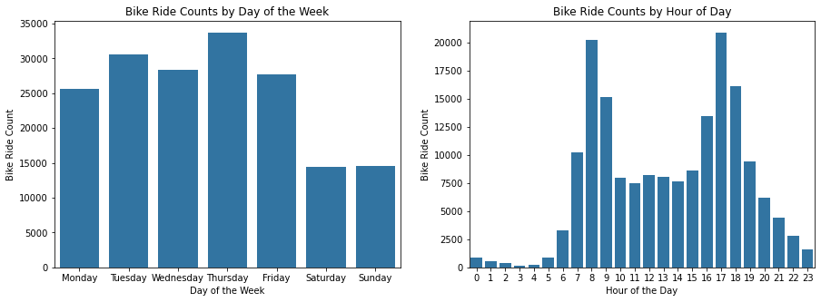

## 6. How the average ride duration varies with gender and user type?

Subscribers and men took the shortest bike trips.

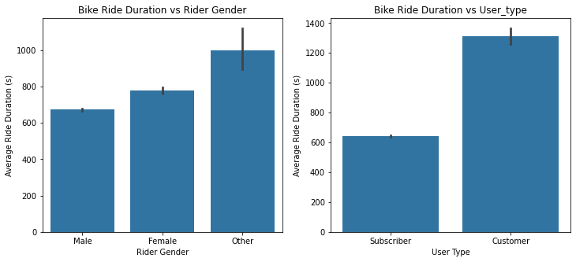